```r
####### Timur Sudak a1277687 ##################################
install.packages("nlme",repos = "http://cran.us.r-project.org")
install.packages("ISLR",repos = "http://cran.us.r-project.org")
install.packages("dummy",repos = "http://cran.us.r-project.org")
install.packages("MASS",repos = "http://cran.us.r-project.org")
install.packages("qqtest",repos = "http://cran.us.r-project.org")
install.packages("caret",repos = "http://cran.us.r-project.org")
install.packages("hydroGOF",repos = "http://cran.us.r-project.org")
install.packages("data.table",repos = "http://cran.us.r-project.org")
install.packages("leaps",repos = "http://cran.us.r-project.org")
install.packages('VIF',repos = "http://cran.us.r-project.org")
install.packages("rpart",repos = "http://cran.us.r-project.org")
install.packages("randomForest",repos = "http://cran.us.r-project.org")
install.packages("olsrr",repos = "http://cran.us.r-project.org")
install.packages("fmsb",repos = "http://cran.us.r-project.org")
install.packages("forecast",repos = "http://cran.us.r-project.org")
install.packages("ridge",repos = "http://cran.us.r-project.org")
install.packages("car",repos = "http://cran.us.r-project.org")
install.packages("xlsx",repos = "http://cran.us.r-project.org")
```

```r
library("randomForest")
library("rpart")
library("VIF")
library("leaps")
library("data.table")
library("MASS")
library("hydroGOF")
library("ISLR")
library("qqtest")
library("nlme")
library("caret")
library("dummy")
library("olsrr")
library("fmsb")
library("forecast")
library("ridge")
library("car")
library("xlsx")
```

```r
setwd("C:/Users/User/Documents/Data for R/Going through Timw Series/Projects in time series/from Nastia")
ant_d = read.csv("Anti-Depressiva.csv", header=TRUE, sep= ";")
ant_d
```

| y | age | TRT |
| --- | --- | --- |
| 56 | 21 | A |
| 41 | 23 | B |
| 40 | 30 | B |
| 28 | 19 | C |
| 55 | 28 | A |
| 25 | 23 | C |
| 46 | 33 | B |
| 71 | 67 | C |
| 48 | 42 | B |
| 63 | 33 | A |
| 52 | 33 | A |
| 62 | 56 | C |
| 50 | 45 | C |
| 45 | 43 | B |
| 58 | 38 | A |
| 46 | 37 | C |
| 58 | 43 | B |
| 34 | 27 | C |
| 65 | 43 | A |
| 55 | 45 | B |
| 57 | 48 | B |
| 59 | 47 | C |
| 64 | 48 | A |
| 61 | 53 | A |
| 62 | 58 | B |
| 36 | 29 | C |
| 69 | 53 | A |
| 47 | 29 | B |
| 73 | 58 | A |
| 64 | 66 | B |
| 60 | 67 | B |
| 62 | 63 | A |
| 71 | 59 | C |
| 62 | 51 | C |
| 70 | 67 | A |
| 71 | 63 | C |

Construct a predictive model with “y” as target variable! Apply different contrasting strategies and interpret the parameter estimates! Now we want to do these two points in one exercise. We will do two contrasting strategies and will fit the model for every strategy.

```r
options(contrasts=c("contr.treatment", "contr.poly"))
contrasts(ant_d[,3])
summary(lm(y~age+TRT, data = ant_d))
```

|  | B | C |
| --- | --- | --- |
| A | 0 | 0 |
| B | 1 | 0 |
| C | 0 | 1 |

```
Call:
lm(formula = y ~ age + TRT, data = ant_d)

Residuals:
     Min       1Q   Median       3Q      Max
-12.5732  -3.3922   0.9829   3.9613   9.5062

Coefficients:
             Estimate Std. Error t value Pr(>|t|)
(Intercept)  32.54335    3.58105   9.088 2.23e-10 ***
age           0.66446    0.06978   9.522 7.42e-11 ***
TRTB         -9.80758    2.46471  -3.979 0.000371 ***
TRTC        -10.25276    2.46542  -4.159 0.000224 ***
---
Signif. codes:  0 '***' 0.001 '**' 0.01 '*' 0.05 '.' 0.1 ' ' 1

Residual standard error: 6.035 on 32 degrees of freedom
Multiple R-squared:  0.784,	Adjusted R-squared:  0.7637
F-statistic: 38.71 on 3 and 32 DF,  p-value: 9.287e-11
```

All Coefficients are signifikant at significance level of 0.05. The model explains 76.37 % of the variation.

Interpretation of the treatment contrast:

For the group A the model would be the baseline. We would get our model for group B if we add our coefficient TRTB it means that measurement success for group B would be on -9.80758 smaller. And if we add TRTC our measurement success would be smaller on -10.25276 than our baseline.

```r
options(contrasts=c("contr.sum", "contr.poly"))
contrasts(ant_d[,3])
summary(lm(y~age+TRT, data = ant_d))
```

| A | 1 | 0 |
| --- | --- | --- |
| B | 0 | 1 |
| C | -1 | -1 |

```
Call:
lm(formula = y ~ age + TRT, data = ant_d)

Residuals:
     Min       1Q   Median       3Q      Max
-12.5732  -3.3922   0.9829   3.9613   9.5062

Coefficients:
            Estimate Std. Error t value Pr(>|t|)
(Intercept) 25.85657    3.23845   7.984 4.10e-09 ***
age          0.66446    0.06978   9.522 7.42e-11 ***
TRT1         6.68678    1.42341   4.698 4.77e-05 ***
TRT2        -3.12080    1.42259  -2.194   0.0356 *
---
Signif. codes:  0 '***' 0.001 '**' 0.01 '*' 0.05 '.' 0.1 ' ' 1

Residual standard error: 6.035 on 32 degrees of freedom
Multiple R-squared:  0.784,	Adjusted R-squared:  0.7637
F-statistic: 38.71 on 3 and 32 DF,  p-value: 9.287e-11
```

All Coefficients are signifikant at level of 0.05. The model explains 76.37 % of the variation.

Interpretation of the sum contrast:

Intercept is the overall mean across all groups.It means that overall measurement sucess is 25.85657. The second coefficient is the average slope between overall mean and age. If we increase age by one unit then our overall mesurement sucess will increase on 0.66446 across all groups. The coefficient TRT1 is the difference between overall mean and group 1. Measurement sucess for group 1 would be higher on 6.68678 than our overall measurement sucess. And TRT2 coefficient is the difference between overall mean and group 2. Measurement sucess for group 2 would be smaller on -3.12080 than our averall measurement sucess.

Which conclusions do you reach regarding the predictor “TRT”, which indicates three different treatments?

We showed that a predictor TRT does improve our Adjusted R^(2), it means increased explanation of the variation. So therefore we have to include this predictor in our model.

Here we see some examples of three different models and their comparison of Adjusted R2 values:

```r
summary(lm(y~age, data = ant_d)) #Here our Adjusted R2 is 0.624.
```

```
Call:
lm(formula = y ~ age, data = ant_d)

Residuals:
     Min       1Q   Median       3Q      Max
-15.8916  -5.7463  -0.4105   4.7013  16.4607

Coefficients:
            Estimate Std. Error t value Pr(>|t|)
(Intercept) 25.33935    4.08258   6.207 4.65e-07 ***
age          0.67619    0.08797   7.687 6.15e-09 ***
---
Signif. codes:  0 '***' 0.001 '**' 0.01 '*' 0.05 '.' 0.1 ' ' 1

Residual standard error: 7.613 on 34 degrees of freedom
Multiple R-squared:  0.6347,	Adjusted R-squared:  0.624
F-statistic: 59.08 on 1 and 34 DF,  p-value: 6.155e-09
```

```r
summary(lm(y~age+TRT, data = ant_d)) # Here our Adjusted R2 is 0.7637.
```

```
Call:
lm(formula = y ~ age + TRT, data = ant_d)

Residuals:
     Min       1Q   Median       3Q      Max
-12.5732  -3.3922   0.9829   3.9613   9.5062

Coefficients:
            Estimate Std. Error t value Pr(>|t|)
(Intercept) 25.85657    3.23845   7.984 4.10e-09 ***
age          0.66446    0.06978   9.522 7.42e-11 ***
TRT1         6.68678    1.42341   4.698 4.77e-05 ***
TRT2        -3.12080    1.42259  -2.194   0.0356 *
---
Signif. codes:  0 '***' 0.001 '**' 0.01 '*' 0.05 '.' 0.1 ' ' 1

Residual standard error: 6.035 on 32 degrees of freedom
Multiple R-squared:  0.784,	Adjusted R-squared:  0.7637
F-statistic: 38.71 on 3 and 32 DF,  p-value: 9.287e-11
```

```r
summary(lm(y~age*TRT, data = ant_d)) # here our Adjusted R2 is 0.9001.
```

```
Call:
lm(formula = y ~ age * TRT, data = ant_d)

Residuals:
    Min      1Q  Median      3Q     Max
-6.4366 -2.7637  0.1887  2.9075  6.5634

Coefficients:
            Estimate Std. Error t value Pr(>|t|)
(Intercept) 27.54839    2.12264  12.978 7.68e-14 ***
age          0.62919    0.04574  13.757 1.71e-14 ***
TRT1        19.96720    3.06317   6.518 3.31e-07 ***
TRT2         1.36981    3.06673   0.447    0.658
age:TRT1    -0.29869    0.06562  -4.552 8.23e-05 ***
age:TRT2    -0.10551    0.06641  -1.589    0.123
---
Signif. codes:  0 '***' 0.001 '**' 0.01 '*' 0.05 '.' 0.1 ' ' 1

Residual standard error: 3.925 on 30 degrees of freedom
Multiple R-squared:  0.9143,	Adjusted R-squared:  0.9001
F-statistic: 64.04 on 5 and 30 DF,  p-value: 4.264e-15
```

```r
#Compare and interpret models with and without interaction terms!
einf_mod = lm(y~age+TRT, data = ant_d)
mod_int <-  lm(y~age*TRT, data = ant_d)
summary(mod_int)
```

```
Call:
lm(formula = y ~ age * TRT, data = ant_d)

Residuals:
    Min      1Q  Median      3Q     Max
-6.4366 -2.7637  0.1887  2.9075  6.5634

Coefficients:
            Estimate Std. Error t value Pr(>|t|)
(Intercept) 27.54839    2.12264  12.978 7.68e-14 ***
age          0.62919    0.04574  13.757 1.71e-14 ***
TRT1        19.96720    3.06317   6.518 3.31e-07 ***
TRT2         1.36981    3.06673   0.447    0.658
age:TRT1    -0.29869    0.06562  -4.552 8.23e-05 ***
age:TRT2    -0.10551    0.06641  -1.589    0.123
---
Signif. codes:  0 '***' 0.001 '**' 0.01 '*' 0.05 '.' 0.1 ' ' 1

Residual standard error: 3.925 on 30 degrees of freedom
Multiple R-squared:  0.9143,	Adjusted R-squared:  0.9001
F-statistic: 64.04 on 5 and 30 DF,  p-value: 4.264e-15
```

```
                          This is our model with interaction effects.
```

```r
anova(einf_mod,mod_int)
```

| Res.Df | RSS | Df | Sum of Sq | F | Pr(>F) |
| --- | --- | --- | --- | --- | --- |
| 32 | 1165.5747 | NA | NA | NA | NA |
| 30 | 462.1477 | 2 | 703.427 | 22.83124 | 9.410457e-07 |

We see that we have significant difference between two models, our p<0.05. Normally bigger models explain the same amount of variation than smaller model. And in our case because of significance it makes sense to include the interaction term.

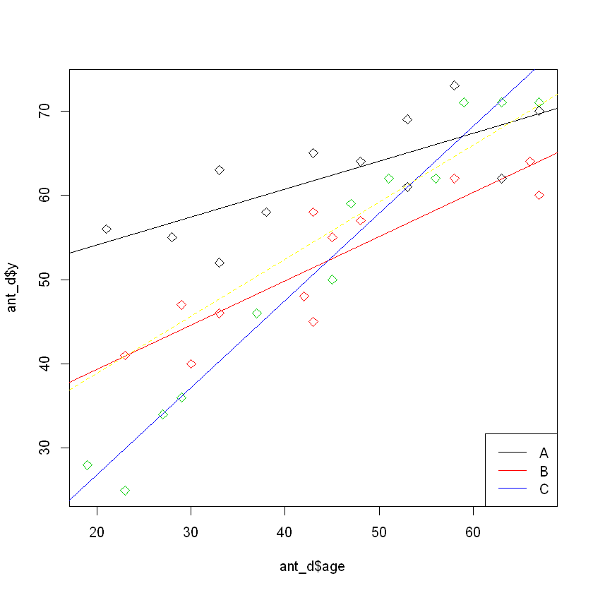

```r
#Visualize the data and the different models estimated
plot(ant_d$y ~ ant_d$age, col = as.numeric(ant_d$TRT), pch = 5)
abline(lm(ant_d$y ~ ant_d$age, subset = ant_d$TRT == "A"), col = "black")
abline(lm(ant_d$y ~ ant_d$age, subset = ant_d$TRT == "B"), col = "red")
abline(lm(ant_d$y ~ ant_d$age, subset = ant_d$TRT == "C"), col = "blue")
abline(lm(ant_d$y ~ ant_d$age), lty = 2,col = "yellow")
legend("bottomright", legend = c("A","B","C"), col = c("black", "red", "blue"), lty = rep(1,3))
```

Here we plot models for three different groups. And one plot for the average model.

```r
####################Aufgabe 2 ########################
Wage_c <- Wage[colnames(Wage)[!(colnames(Wage) %in% c("logwage", "region"))]]
set.seed(100)
train_ind <- sample(1:nrow(Wage_c), round(0.7*nrow(Wage_c)))
Wage_train <- Wage_c[train_ind,]
Wage_test <- Wage_c[-train_ind,]
```

```r
pr1=lm(wage ~ year+age+maritl+race+education+jobclass+health+health_ins, data=Wage_train) # This is our OLS model.
summary(pr1)
```

```
Call:
lm(formula = wage ~ year + age + maritl + race + education +
    jobclass + health + health_ins, data = Wage_train)

Residuals:
   Min     1Q Median     3Q    Max
-96.12 -18.53  -3.30  12.98 212.21

Coefficients:
              Estimate Std. Error t value Pr(>|t|)
(Intercept) -2.397e+03  7.327e+02  -3.271  0.00109 **
year         1.236e+00  3.653e-01   3.383  0.00073 ***
age          3.683e-01  7.285e-02   5.056 4.66e-07 ***
maritl1     -6.581e+00  2.644e+00  -2.489  0.01290 *
maritl2      1.082e+01  2.322e+00   4.657 3.41e-06 ***
maritl3     -6.211e+00  7.307e+00  -0.850  0.39538
maritl4     -1.457e+00  3.105e+00  -0.469  0.63893
race1        4.920e+00  2.027e+00   2.427  0.01529 *
race2       -2.536e+00  2.598e+00  -0.976  0.32916
race3        2.359e+00  2.898e+00   0.814  0.41580
education1  -2.256e+01  2.109e+00 -10.699  < 2e-16 ***
education2  -1.498e+01  1.324e+00 -11.314  < 2e-16 ***
education3  -4.006e+00  1.489e+00  -2.691  0.00717 **
education4   1.037e+01  1.446e+00   7.175 9.99e-13 ***
jobclass1   -1.592e+00  7.814e-01  -2.037  0.04178 *
health1     -4.452e+00  8.444e-01  -5.272 1.49e-07 ***
health_ins1  7.896e+00  8.195e-01   9.636  < 2e-16 ***
---
Signif. codes:  0 '***' 0.001 '**' 0.01 '*' 0.05 '.' 0.1 ' ' 1

Residual standard error: 33.52 on 2083 degrees of freedom
Multiple R-squared:  0.359,	Adjusted R-squared:  0.3541
F-statistic: 72.91 on 16 and 2083 DF,  p-value: < 2.2e-16
```

At first we train our model. In this case we get OLS. Then we will compare different models with different transformation in OLS and another methods.

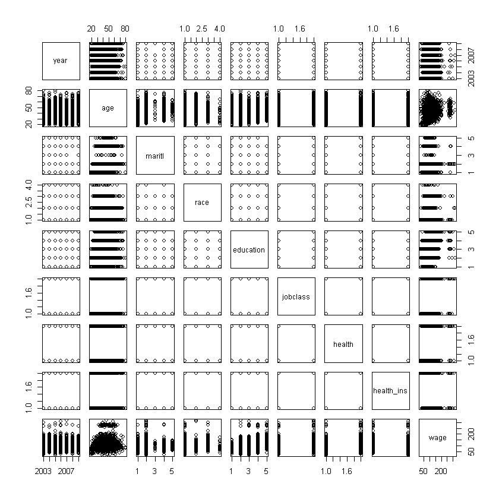

```r
plot(Wage_train)
```

We have to give attention to the predictors with some correlation. Because we can include them in the model as interaction terms

```r
pr2=lm(wage ~ year*age+maritl+race*age+education*age+jobclass+health+health_ins, data=Wage_train)
summary(pr2)
```

```
Call:
lm(formula = wage ~ year * age + maritl + race * age + education *
    age + jobclass + health + health_ins, data = Wage_train)

Residuals:
     Min       1Q   Median       3Q      Max
-100.106  -18.378   -3.285   12.994  210.709

Coefficients:
                 Estimate Std. Error t value Pr(>|t|)
(Intercept)    -4.863e+03  2.734e+03  -1.779   0.0754 .
year            2.464e+00  1.363e+00   1.808   0.0707 .
age             5.600e+01  6.150e+01   0.911   0.3626
maritl1        -6.666e+00  2.648e+00  -2.518   0.0119 *
maritl2         1.097e+01  2.333e+00   4.700 2.77e-06 ***
maritl3        -6.461e+00  7.344e+00  -0.880   0.3790
maritl4        -1.889e+00  3.110e+00  -0.607   0.5436
race1           5.266e+00  6.977e+00   0.755   0.4505
race2           4.006e+00  8.961e+00   0.447   0.6549
race3           1.166e+01  1.048e+01   1.112   0.2661
education1     -6.523e+00  7.144e+00  -0.913   0.3613
education2     -5.265e+00  4.831e+00  -1.090   0.2759
education3     -1.364e+01  5.476e+00  -2.490   0.0128 *
education4      1.317e+01  5.621e+00   2.343   0.0192 *
jobclass1      -1.632e+00  7.813e-01  -2.089   0.0369 *
health1        -4.356e+00  8.437e-01  -5.163 2.66e-07 ***
health_ins1     8.111e+00  8.238e-01   9.846  < 2e-16 ***
year:age       -2.770e-02  3.066e-02  -0.903   0.3664
age:race1      -2.674e-02  1.732e-01  -0.154   0.8773
age:race2      -1.570e-01  2.095e-01  -0.750   0.4535
age:race3      -2.312e-01  2.509e-01  -0.922   0.3569
age:education1 -3.770e-01  1.645e-01  -2.292   0.0220 *
age:education2 -2.220e-01  1.089e-01  -2.038   0.0417 *
age:education3  2.424e-01  1.272e-01   1.906   0.0568 .
age:education4 -6.085e-02  1.268e-01  -0.480   0.6312
---
Signif. codes:  0 '***' 0.001 '**' 0.01 '*' 0.05 '.' 0.1 ' ' 1

Residual standard error: 33.44 on 2075 degrees of freedom
Multiple R-squared:  0.3644,	Adjusted R-squared:  0.3571
F-statistic: 49.57 on 24 and 2075 DF,  p-value: < 2.2e-16
```

Here i tried to trnasform variables with including of interaction terms. I choosed variables with the biggest correlation. But it didn't improve our model so well. We could also do some Polynomial or log distribution but as we see below it doesn't make so much sense because our data doesn't show any non-linearities.

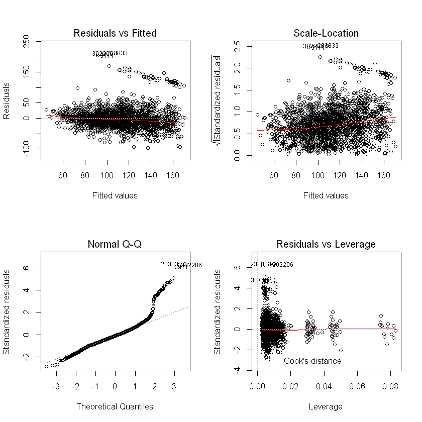

```r
layout(matrix(c(1,2,3,4),2,2))
plot(pr1)
```

As we can conclude from this plots there are no non-linearities.

```r
pd_pr1 = predict(pr1, newdata=Wage_test) # Here we get fitted values.
rss_ols = mean((Wage_test[,"wage"]-pd_pr1)^(2)) # Here we get our Av. RSS for OLS.
rss_ols
```

1244.23861249978

Here we compute average RSS for different methods and compare them. As we showed above it doesn't make so much sense to transform something or add some interactions we will use just our classic models with predictors.

```r
# For the regression Tree.

set.seed(100)
rg_tree = rpart(wage ~ .,Wage_train, cp = 0.0001)
printcp(rg_tree)
regression_trees_pred <- predict(rg_tree, Wage_test)
rss_reg_tree <- mean((Wage_test$wage - regression_trees_pred)^(2))
```

```
Regression tree:
rpart(formula = wage ~ ., data = Wage_train, cp = 1e-04)

Variables actually used in tree construction:
[1] age        education  health     health_ins jobclass   maritl     race
[8] year

Root node error: 3651382/2100 = 1738.8

n= 2100

            CP nsplit rel error  xerror     xstd
1   0.19381157      0   1.00000 1.00036 0.056314
2   0.03370416      1   0.80619 0.80702 0.047707
3   0.03067754      2   0.77248 0.79504 0.047004
```

[output cut: 119 more lines]

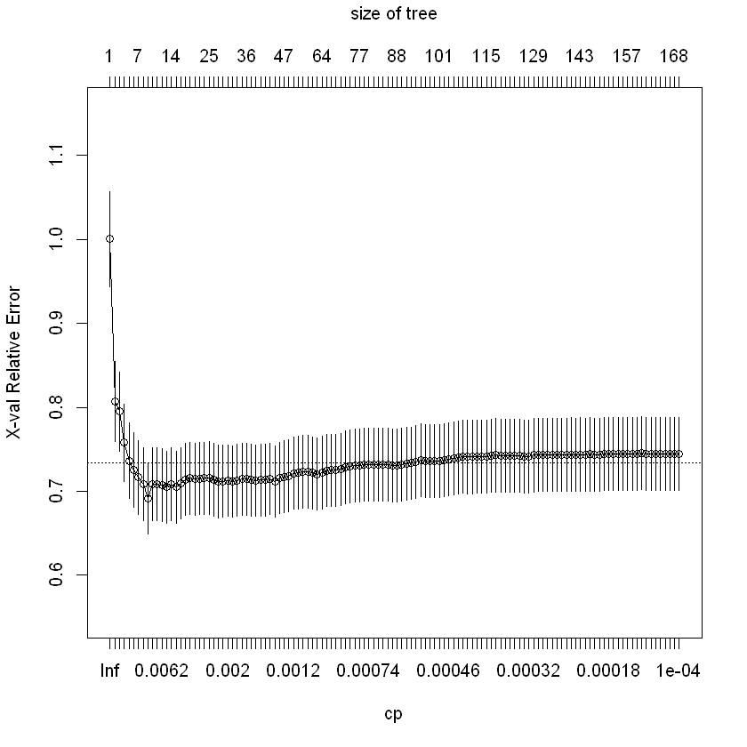

```r
plotcp(rg_tree)
```

```r
set.seed(100)
rg_tree = rpart(wage ~ .,Wage_train, cp = 0.00208298)
regression_trees_pred <- predict(rg_tree, Wage_test)
rss_reg_tree <- mean((Wage_test$wage - regression_trees_pred)^(2))
rss_reg_tree
```

1328.16261410069

This is our average RSS for the Regression Tree.

```r
### Random Forest.
rnd_forest_md = randomForest(wage~ ., Wage_train, ntree=50, norm.votes=FALSE)
prd_ranfor = predict(rnd_forest_md, Wage_test)
mean((Wage_test$wage-prd_ranfor)^(2))
```

1253.4966565669

As we know that in Random Forest the more trees we do the better model we get. Now we will try different numbers of trees to check whether it makes a big difference to make number of tree real big.

```r
rnd_forest_md = randomForest(wage~ ., Wage_train, ntree=100, norm.votes=FALSE)
prd_ranfor = predict(rnd_forest_md, Wage_test)
mean((Wage_test$wage-prd_ranfor)^(2))
```

1246.05387203512

```r
rnd_forest_md = randomForest(wage~ ., Wage_train, ntree=3000, norm.votes=FALSE)
prd_ranfor = predict(rnd_forest_md, Wage_test)
mean((Wage_test$wage-prd_ranfor)^(2))
```

1239.65822298803

As we see that influence of the number of the trees for our average RSS is not so big. We needed 3000 Trees to get our average less than OLS. Therefore i think that some average number of trees for our model would be enough.

```
                      ############################Aufgabe 3 ##################################
```

```r
r_est = read.table("realestate.txt", header=TRUE) # Real Estate
r_est
```

| SalesPrice | SqFeet | Beds | Baths | AirCond | Garage | Pool | Year | Quality | Style | Lot | Highway |
| --- | --- | --- | --- | --- | --- | --- | --- | --- | --- | --- | --- |
| 360.00 | 3.032 | 4 | 4 | 1 | 2 | 0 | 1972 | 2 | 1 | 22.221 | 0 |
| 340.00 | 2.058 | 4 | 2 | 1 | 2 | 0 | 1976 | 2 | 1 | 22.912 | 0 |
| 250.00 | 1.780 | 4 | 3 | 1 | 2 | 0 | 1980 | 2 | 1 | 21.345 | 0 |
| 205.50 | 1.638 | 4 | 2 | 1 | 2 | 0 | 1963 | 2 | 1 | 17.342 | 0 |
| 275.50 | 2.196 | 4 | 3 | 1 | 2 | 0 | 1968 | 2 | 7 | 21.786 | 0 |
| 248.00 | 1.966 | 4 | 3 | 1 | 5 | 1 | 1972 | 2 | 1 | 18.902 | 0 |
| 229.90 | 2.216 | 3 | 2 | 1 | 2 | 0 | 1972 | 2 | 7 | 18.639 | 0 |
| 150.00 | 1.597 | 2 | 1 | 1 | 1 | 0 | 1955 | 2 | 1 | 22.112 | 0 |
| 195.00 | 1.622 | 3 | 2 | 1 | 2 | 0 | 1975 | 3 | 1 | 14.321 | 0 |
| 160.00 | 1.976 | 3 | 3 | 0 | 1 | 0 | 1918 | 3 | 1 | 32.358 | 0 |
| 190.00 | 2.812 | 7 | 5 | 0 | 2 | 1 | 1966 | 3 | 7 | 56.639 | 0 |
| 559.00 | 2.791 | 3 | 4 | 1 | 3 | 0 | 1992 | 1 | 1 | 30.595 | 0 |
| 535.00 | 3.381 | 5 | 4 | 1 | 3 | 0 | 1988 | 1 | 7 | 23.172 | 0 |
| 525.00 | 3.459 | 5 | 4 | 1 | 2 | 0 | 1978 | 1 | 5 | 35.351 | 0 |
| 299.90 | 2.090 | 3 | 3 | 1 | 2 | 0 | 1987 | 2 | 1 | 24.025 | 0 |
| 527.00 | 3.232 | 5 | 5 | 1 | 2 | 0 | 1984 | 2 | 6 | 21.445 | 0 |
| 169.90 | 1.502 | 2 | 2 | 1 | 2 | 0 | 1956 | 2 | 1 | 28.958 | 0 |
| 335.25 | 2.747 | 3 | 4 | 1 | 2 | 0 | 1993 | 2 | 7 | 22.241 | 0 |
| 323.90 | 2.890 | 4 | 3 | 1 | 2 | 0 | 1954 | 2 | 7 | 41.992 | 0 |
| 200.00 | 1.825 | 3 | 3 | 1 | 2 | 0 | 1957 | 2 | 1 | 30.266 | 0 |
| 211.00 | 1.578 | 4 | 3 | 1 | 2 | 0 | 1986 | 2 | 2 | 18.829 | 0 |
| 212.00 | 1.763 | 3 | 3 | 1 | 2 | 0 | 1959 | 2 | 1 | 24.726 | 0 |
| 245.00 | 2.517 | 4 | 3 | 1 | 2 | 0 | 1965 | 2 | 1 | 23.261 | 0 |
| 140.40 | 1.872 | 3 | 2 | 1 | 2 | 0 | 1985 | 2 | 3 | 24.017 | 0 |
| 295.00 | 3.266 | 3 | 3 | 1 | 2 | 0 | 1908 | 2 | 6 | 24.881 | 0 |
| 170.90 | 2.020 | 1 | 2 | 1 | 1 | 0 | 1956 | 2 | 1 | 21.385 | 0 |
| 229.00 | 2.164 | 4 | 2 | 1 | 2 | 0 | 1965 | 2 | 1 | 28.291 | 0 |
| 218.50 | 2.080 | 3 | 2 | 1 | 2 | 1 | 1959 | 2 | 1 | 14.752 | 0 |
| 160.00 | 2.208 | 2 | 2 | 1 | 2 | 0 | 1985 | 2 | 7 | 8.058 | 0 |
| 259.00 | 3.048 | 6 | 4 | 1 | 3 | 0 | 1960 | 2 | 7 | 29.307 | 0 |
| ... | ... | ... | ... | ... | ... | ... | ... | ... | ... | ... | ... |
| 175.00 | 2.035 | 4 | 2 | 1 | 3 | 0 | 1962 | 3 | 7 | 20.131 | 0 |
| 147.00 | 1.534 | 3 | 2 | 0 | 1 | 0 | 1955 | 3 | 3 | 15.361 | 0 |
| 155.00 | 1.624 | 2 | 2 | 1 | 2 | 0 | 1955 | 3 | 1 | 16.721 | 0 |
| 150.00 | 1.700 | 4 | 2 | 1 | 1 | 0 | 1954 | 3 | 1 | 15.391 | 0 |
| 165.00 | 1.630 | 3 | 2 | 1 | 2 | 0 | 1978 | 3 | 2 | 24.963 | 0 |
| 147.00 | 1.526 | 3 | 2 | 1 | 1 | 0 | 1957 | 3 | 1 | 15.007 | 0 |
| 146.25 | 1.672 | 3 | 1 | 1 | 2 | 0 | 1949 | 3 | 1 | 22.617 | 0 |
| 177.50 | 1.588 | 4 | 2 | 1 | 2 | 0 | 1980 | 3 | 2 | 21.925 | 0 |
| 153.65 | 1.752 | 4 | 2 | 1 | 2 | 0 | 1950 | 3 | 6 | 9.126 | 0 |
| 199.50 | 1.674 | 4 | 2 | 0 | 2 | 0 | 1947 | 3 | 1 | 33.237 | 0 |
| 186.00 | 1.980 | 3 | 1 | 0 | 1 | 0 | 1927 | 3 | 6 | 47.679 | 0 |
| 139.90 | 1.396 | 1 | 1 | 0 | 2 | 0 | 1950 | 3 | 1 | 25.879 | 0 |
| 160.00 | 1.178 | 1 | 1 | 0 | 2 | 0 | 1959 | 3 | 1 | 9.941 | 0 |
| 125.00 | 1.263 | 2 | 2 | 0 | 0 | 0 | 1955 | 3 | 1 | 12.357 | 0 |
| 359.90 | 2.377 | 5 | 2 | 1 | 2 | 0 | 1937 | 3 | 6 | 51.005 | 0 |
| 184.50 | 1.304 | 3 | 1 | 1 | 2 | 0 | 1951 | 3 | 1 | 21.305 | 0 |
| 155.00 | 1.340 | 3 | 1 | 0 | 0 | 0 | 1952 | 3 | 1 | 5.666 | 0 |
| 150.00 | 1.559 | 2 | 1 | 0 | 2 | 0 | 1952 | 3 | 1 | 23.999 | 0 |
| 146.00 | 1.412 | 1 | 2 | 1 | 0 | 0 | 1920 | 3 | 1 | 4.560 | 0 |
| 129.00 | 1.198 | 2 | 2 | 1 | 2 | 0 | 1925 | 3 | 1 | 20.918 | 0 |
| 145.00 | 1.424 | 2 | 1 | 1 | 2 | 0 | 1947 | 3 | 1 | 16.414 | 0 |
| 200.00 | 1.370 | 4 | 1 | 0 | 1 | 0 | 1925 | 3 | 4 | 8.000 | 0 |
| 149.90 | 1.584 | 3 | 2 | 1 | 2 | 0 | 1957 | 3 | 1 | 13.514 | 0 |
| 132.00 | 1.567 | 2 | 1 | 1 | 1 | 0 | 1934 | 3 | 4 | 12.249 | 0 |
| 136.90 | 1.409 | 2 | 1 | 0 | 1 | 0 | 1951 | 3 | 1 | 28.421 | 0 |
| 137.00 | 1.655 | 2 | 1 | 0 | 1 | 0 | 1935 | 3 | 1 | 54.651 | 0 |
| 185.00 | 1.944 | 3 | 2 | 1 | 2 | 0 | 1939 | 3 | 6 | 17.999 | 0 |
| 133.50 | 1.922 | 3 | 1 | 0 | 2 | 0 | 1950 | 3 | 1 | 14.805 | 0 |
| 124.00 | 1.480 | 3 | 2 | 1 | 2 | 0 | 1953 | 3 | 1 | 28.351 | 0 |
| 95.50 | 1.184 | 2 | 1 | 0 | 1 | 0 | 1951 | 3 | 1 | 14.786 | 0 |

```r
d_V <- lm(SalesPrice~SqFeet+Beds+Baths+AirCond+Garage+Pool+Year+Quality+Style+Lot+Highway,data = r_est)
ols_step_all_possible(d_V)
```

|  | mindex | n | predictors | rsquare | adjr | predrsq | cp | aic | sbic | sbc | msep | fpe | apc | hsp |
| --- | --- | --- | --- | --- | --- | --- | --- | --- | --- | --- | --- | --- | --- | --- |
| 1 | 1 | 1 | SqFeet | 0.676943525 | 0.6763210657 | 0.673082541 | 274.2860 | 6026.136 | 4546.003 | 6038.903 | 6153.518 | 6153.427 | 0.3255463 | 11.833775 |
| 8 | 2 | 1 | Quality | 0.572302678 | 0.5714785987 | 0.568433754 | 530.5905 | 6172.323 | 4691.273 | 6185.090 | 8146.696 | 8146.576 | 0.4309936 | 15.666839 |
| 3 | 3 | 1 | Baths | 0.488229039 | 0.4872429679 | 0.482659152 | 736.5182 | 6265.822 | 4784.268 | 6278.589 | 9748.115 | 9747.971 | 0.5157152 | 18.746513 |
| 5 | 4 | 1 | Garage | 0.331606045 | 0.3303181951 | 0.323859725 | 1120.1464 | 6404.930 | 4922.739 | 6417.697 | 12731.439 | 12731.251 | 0.6735454 | 24.483718 |
| 7 | 5 | 1 | Year | 0.306226804 | 0.3048900539 | 0.298226217 | 1182.3096 | 6424.346 | 4942.077 | 6437.113 | 13214.858 | 13214.663 | 0.6991202 | 25.413377 |
| 2 | 6 | 1 | Beds | 0.186226514 | 0.1846585499 | 0.180237534 | 1476.2352 | 6507.465 | 5024.885 | 6520.232 | 15500.601 | 15500.372 | 0.8200453 | 29.809068 |
| 9 | 7 | 1 | Style | 0.131143852 | 0.1294697559 | 0.123622583 | 1611.1532 | 6541.588 | 5058.892 | 6554.355 | 16549.805 | 16549.560 | 0.8755525 | 31.826782 |
| 4 | 8 | 1 | AirCond | 0.082941782 | 0.0811748104 | 0.077823703 | 1729.2181 | 6569.718 | 5086.932 | 6582.486 | 17467.948 | 17467.691 | 0.9241261 | 33.592456 |
| 10 | 9 | 1 | Lot | 0.048944000 | 0.0471115218 | 0.041269842 | 1812.4913 | 6588.684 | 5105.839 | 6601.451 | 18115.532 | 18115.264 | 0.9583859 | 34.837818 |
| 6 | 10 | 1 | Pool | 0.021917262 | 0.0200327099 | 0.014411550 | 1878.6899 | 6603.283 | 5120.394 | 6616.050 | 18630.332 | 18630.057 | 0.9856209 | 35.827825 |
| 11 | 11 | 1 | Highway | 0.002562165 | 0.0006403195 | -0.002873205 | 1926.0977 | 6613.492 | 5130.573 | 6626.259 | 18999.004 | 18998.723 | 1.0051252 | 36.536816 |
| 18 | 12 | 2 | SqFeet Quality | 0.741477771 | 0.7404796160 | 0.736808161 | 118.2175 | 5912.034 | 4432.374 | 5929.057 | 4943.331 | 4943.149 | 0.2615167 | 9.506476 |
| 17 | 13 | 2 | SqFeet Year | 0.721477711 | 0.7204023358 | 0.716589534 | 167.2051 | 5950.857 | 4470.793 | 5967.880 | 5325.762 | 5325.566 | 0.2817484 | 10.241926 |
| 19 | 14 | 2 | SqFeet Style | 0.711146359 | 0.7100310943 | 0.705508843 | 192.5104 | 5969.833 | 4489.578 | 5986.856 | 5523.313 | 5523.109 | 0.2921994 | 10.621834 |
| 15 | 15 | 2 | SqFeet Garage | 0.702663222 | 0.7015152033 | 0.697519748 | 213.2888 | 5984.913 | 4504.509 | 6001.936 | 5685.523 | 5685.313 | 0.3007808 | 10.933779 |
| 13 | 16 | 2 | SqFeet Baths | 0.689968383 | 0.6887713492 | 0.684549827 | 244.3832 | 6006.696 | 4526.081 | 6023.719 | 5928.268 | 5928.049 | 0.3136227 | 11.400599 |
| 20 | 17 | 2 | SqFeet Lot | 0.685462963 | 0.6842485340 | 0.679176135 | 255.4187 | 6014.212 | 4533.526 | 6031.235 | 6014.418 | 6014.196 | 0.3181803 | 11.566274 |
| 14 | 18 | 2 | SqFeet AirCond | 0.681831681 | 0.6806032321 | 0.677289374 | 264.3130 | 6020.193 | 4539.450 | 6037.216 | 6083.853 | 6083.629 | 0.3218537 | 11.699804 |
| 12 | 19 | 2 | SqFeet Beds | 0.678413743 | 0.6771720969 | 0.672737196 | 272.6848 | 6025.760 | 4544.965 | 6042.783 | 6149.210 | 6148.983 | 0.3253112 | 11.825490 |
| 16 | 20 | 2 | SqFeet Pool | 0.677159360 | 0.6759128706 | 0.671532363 | 275.7573 | 6027.788 | 4546.974 | 6044.811 | 6173.195 | 6172.967 | 0.3265801 | 11.871617 |
| 21 | 21 | 2 | SqFeet Highway | 0.676944006 | 0.6756966853 | 0.672112555 | 276.2848 | 6028.135 | 4547.319 | 6045.158 | 6177.313 | 6177.085 | 0.3267980 | 11.879536 |
| 35 | 22 | 2 | Baths Quality | 0.629313368 | 0.6278821455 | 0.623597048 | 392.9500 | 6099.789 | 4618.335 | 6116.812 | 7088.082 | 7087.820 | 0.3749803 | 13.631028 |
| 48 | 23 | 2 | Garage Quality | 0.610359396 | 0.6088549922 | 0.604651754 | 439.3753 | 6125.770 | 4644.099 | 6142.793 | 7450.510 | 7450.235 | 0.3941538 | 14.328010 |
| 27 | 24 | 2 | Beds Quality | 0.592903126 | 0.5913313237 | 0.587483023 | 482.1323 | 6148.604 | 4666.749 | 6165.627 | 7784.300 | 7784.013 | 0.4118123 | 14.969919 |
| 62 | 25 | 2 | Quality Lot | 0.591050414 | 0.5894714580 | 0.585582665 | 486.6703 | 6150.970 | 4669.096 | 6167.993 | 7819.727 | 7819.438 | 0.4136865 | 15.038047 |
| 57 | 26 | 2 | Year Quality | 0.584662074 | 0.5830584529 | 0.579172275 | 502.3177 | 6159.045 | 4677.108 | 6176.068 | 7941.881 | 7941.588 | 0.4201488 | 15.272962 |
| 61 | 27 | 2 | Quality Style | 0.582668816 | 0.5810574985 | 0.576379107 | 507.1999 | 6161.540 | 4679.583 | 6178.563 | 7979.995 | 7979.701 | 0.4221651 | 15.346258 |
| 53 | 28 | 2 | Pool Quality | 0.575072039 | 0.5734313905 | 0.569794892 | 525.8073 | 6170.938 | 4688.909 | 6187.961 | 8125.257 | 8124.957 | 0.4298499 | 15.625610 |
| 63 | 29 | 2 | Quality Highway | 0.573568918 | 0.5719224663 | 0.568553276 | 529.4890 | 6172.778 | 4690.735 | 6189.801 | 8153.999 | 8153.698 | 0.4313704 | 15.680883 |
| 42 | 30 | 2 | AirCond Quality | 0.573050753 | 0.5714022999 | 0.568250514 | 530.7582 | 6173.411 | 4691.362 | 6190.434 | 8163.907 | 8163.606 | 0.4318946 | 15.699937 |
| ... | ... | ... | ... | ... | ... | ... | ... | ... | ... | ... | ... | ... | ... | ... |
| 1999 | 2018 | 9 | SqFeet Beds Baths AirCond Pool Year Style Lot Highway | 0.7719683 | 0.7679521 | 0.7585629 | 57.53471 | 5860.650 | 4380.763 | 5907.463 | 4480.703 | 4478.917 | 0.2369566 | 8.616801 |
| 2019 | 2019 | 9 | SqFeet Baths AirCond Garage Pool Year Quality Lot Highway | 0.7716052 | 0.7675826 | 0.7596010 | 58.42407 | 5861.479 | 4381.562 | 5908.292 | 4487.838 | 4486.049 | 0.2373339 | 8.630522 |
| 1998 | 2020 | 9 | SqFeet Beds Baths AirCond Pool Year Quality Lot Highway | 0.7702827 | 0.7662368 | 0.7579376 | 61.66336 | 5864.487 | 4384.461 | 5911.300 | 4513.824 | 4512.025 | 0.2387082 | 8.680496 |
| 1985 | 2021 | 9 | SqFeet Beds Baths AirCond Garage Pool Year Style Highway | 0.7661179 | 0.7619987 | 0.7539754 | 71.86459 | 5873.848 | 4393.487 | 5920.661 | 4595.661 | 4593.829 | 0.2430360 | 8.837875 |
| 1983 | 2022 | 9 | SqFeet Beds Baths AirCond Garage Pool Year Quality Highway | 0.7622001 | 0.7580119 | 0.7505396 | 81.46069 | 5882.503 | 4401.836 | 5929.316 | 4672.644 | 4670.781 | 0.2471071 | 8.985919 |
| 1989 | 2023 | 9 | SqFeet Beds Baths AirCond Garage Pool Quality Lot Highway | 0.7608196 | 0.7566071 | 0.7486254 | 84.84207 | 5885.519 | 4404.747 | 5932.332 | 4699.770 | 4697.896 | 0.2485416 | 9.038085 |
| 1986 | 2024 | 9 | SqFeet Beds Baths AirCond Garage Pool Year Lot Highway | 0.7536934 | 0.7493553 | 0.7403185 | 102.29680 | 5900.815 | 4419.515 | 5947.628 | 4839.796 | 4837.867 | 0.2559468 | 9.307369 |
| 1990 | 2025 | 9 | SqFeet Beds Baths AirCond Garage Pool Style Lot Highway | 0.7490245 | 0.7446042 | 0.7349501 | 113.73264 | 5910.598 | 4428.968 | 5957.412 | 4931.537 | 4929.571 | 0.2607984 | 9.483795 |
| 2028 | 2026 | 9 | Beds Baths AirCond Garage Pool Year Quality Lot Highway | 0.6747779 | 0.6690499 | 0.6607720 | 295.59039 | 6045.617 | 4559.925 | 6092.430 | 6390.445 | 6387.897 | 0.3379510 | 12.289408 |
| 2035 | 2027 | 9 | Baths AirCond Garage Pool Year Quality Style Lot Highway | 0.6746325 | 0.6689020 | 0.6600620 | 295.94652 | 6045.850 | 4560.151 | 6092.663 | 6393.302 | 6390.753 | 0.3381020 | 12.294902 |
| 2031 | 2028 | 9 | Beds Baths AirCond Garage Year Quality Style Lot Highway | 0.6743164 | 0.6685803 | 0.6599135 | 296.72083 | 6046.356 | 4560.644 | 6093.169 | 6399.514 | 6396.962 | 0.3384305 | 12.306848 |
| 2026 | 2029 | 9 | Beds Baths AirCond Garage Pool Year Quality Style Lot | 0.6736613 | 0.6679137 | 0.6582024 | 298.32533 | 6047.403 | 4561.662 | 6094.216 | 6412.385 | 6409.829 | 0.3391112 | 12.331601 |
| 2033 | 2030 | 9 | Beds Baths Garage Pool Year Quality Style Lot Highway | 0.6717538 | 0.6659726 | 0.6568161 | 302.99744 | 6050.439 | 4564.618 | 6097.252 | 6449.866 | 6447.295 | 0.3410934 | 12.403680 |
| 2030 | 2031 | 9 | Beds Baths AirCond Garage Pool Quality Style Lot Highway | 0.6664841 | 0.6606100 | 0.6517813 | 315.90498 | 6058.737 | 4572.696 | 6105.550 | 6553.413 | 6550.801 | 0.3465694 | 12.602811 |
| 2027 | 2032 | 9 | Beds Baths AirCond Garage Pool Year Quality Style Highway | 0.6624239 | 0.6564783 | 0.6472290 | 325.85003 | 6065.041 | 4578.836 | 6111.855 | 6633.195 | 6630.551 | 0.3507885 | 12.756239 |
| 2032 | 2033 | 9 | Beds Baths AirCond Pool Year Quality Style Lot Highway | 0.6594563 | 0.6534585 | 0.6447211 | 333.11861 | 6069.601 | 4583.278 | 6116.415 | 6691.505 | 6688.838 | 0.3538722 | 12.868375 |
| 2034 | 2034 | 9 | Beds AirCond Garage Pool Year Quality Style Lot Highway | 0.6585403 | 0.6525263 | 0.6436287 | 335.36231 | 6071.001 | 4584.641 | 6117.814 | 6709.505 | 6706.830 | 0.3548241 | 12.902990 |
| 2029 | 2035 | 9 | Beds Baths AirCond Garage Pool Year Style Lot Highway | 0.6047513 | 0.5977900 | 0.5856230 | 467.11165 | 6147.216 | 4659.018 | 6194.029 | 7766.431 | 7763.335 | 0.4107183 | 14.935554 |
| 2041 | 2036 | 10 | SqFeet Beds Baths AirCond Garage Year Quality Style Lot Highway | 0.7919362 | 0.7878565 | 0.7795007 | 10.62605 | 5814.905 | 4336.862 | 5865.974 | 4104.410 | 4102.441 | 0.2170391 | 7.893155 |
| 2044 | 2037 | 10 | SqFeet Beds AirCond Garage Pool Year Quality Style Lot Highway | 0.7917750 | 0.7876921 | 0.7795245 | 11.02090 | 5815.309 | 4337.248 | 5866.378 | 4107.590 | 4105.619 | 0.2172073 | 7.899270 |
| 2043 | 2038 | 10 | SqFeet Beds Baths Garage Pool Year Quality Style Lot Highway | 0.7911738 | 0.7870792 | 0.7784236 | 12.49331 | 5816.811 | 4338.685 | 5867.880 | 4119.449 | 4117.472 | 0.2178344 | 7.922075 |
| 2036 | 2039 | 10 | SqFeet Beds Baths AirCond Garage Pool Year Quality Style Lot | 0.7907014 | 0.7865975 | 0.7775640 | 13.65048 | 5817.988 | 4339.812 | 5869.057 | 4128.768 | 4126.787 | 0.2183272 | 7.939998 |
| 2045 | 2040 | 10 | SqFeet Baths AirCond Garage Pool Year Quality Style Lot Highway | 0.7899758 | 0.7858577 | 0.7773569 | 15.42771 | 5819.791 | 4341.538 | 5870.860 | 4143.082 | 4141.094 | 0.2190841 | 7.967524 |
| 2042 | 2041 | 10 | SqFeet Beds Baths AirCond Pool Year Quality Style Lot Highway | 0.7896805 | 0.7855566 | 0.7767028 | 16.15089 | 5820.523 | 4342.239 | 5871.592 | 4148.906 | 4146.915 | 0.2193921 | 7.978724 |
| 2037 | 2042 | 10 | SqFeet Beds Baths AirCond Garage Pool Year Quality Style Highway | 0.7840221 | 0.7797872 | 0.7718460 | 30.01058 | 5834.355 | 4355.487 | 5885.424 | 4260.529 | 4258.484 | 0.2252946 | 8.193385 |
| 2040 | 2043 | 10 | SqFeet Beds Baths AirCond Garage Pool Quality Style Lot Highway | 0.7790602 | 0.7747281 | 0.7662039 | 42.16403 | 5846.189 | 4366.833 | 5897.258 | 4358.410 | 4356.318 | 0.2304705 | 8.381619 |
| 2039 | 2044 | 10 | SqFeet Beds Baths AirCond Garage Pool Year Style Lot Highway | 0.7761220 | 0.7717322 | 0.7621184 | 49.36085 | 5853.072 | 4373.435 | 5904.141 | 4416.371 | 4414.252 | 0.2335355 | 8.493085 |
| 2038 | 2045 | 10 | SqFeet Beds Baths AirCond Garage Pool Year Quality Lot Highway | 0.7742538 | 0.7698274 | 0.7612240 | 53.93669 | 5857.401 | 4377.590 | 5908.470 | 4453.224 | 4451.087 | 0.2354842 | 8.563956 |
| 2046 | 2046 | 10 | Beds Baths AirCond Garage Pool Year Quality Style Lot Highway | 0.6752917 | 0.6689248 | 0.6593261 | 296.33195 | 6046.793 | 4560.433 | 6097.862 | 6405.419 | 6402.346 | 0.3387153 | 12.318205 |
| 2047 | 2047 | 11 | SqFeet Beds Baths AirCond Garage Pool Year Quality Style Lot Highway | 0.7921918 | 0.7877008 | 0.7786135 | 12.00000 | 5816.265 | 4338.296 | 5871.590 | 4115.507 | 4113.168 | 0.2176067 | 7.914496 |

```r
m= ols_step_all_possible(d_V)
summary(d_V)
```

```
Call:
lm(formula = SalesPrice ~ SqFeet + Beds + Baths + AirCond + Garage +
    Pool + Year + Quality + Style + Lot + Highway, data = r_est)

Residuals:
    Min      1Q  Median      3Q     Max
-186.25  -37.55   -2.36   31.70  293.79

Coefficients:
              Estimate Std. Error t value Pr(>|t|)
(Intercept) -2351.8910   433.9996  -5.419 9.26e-08 ***
SqFeet        129.7452     7.6675  16.921  < 2e-16 ***
Beds           -8.2357     3.5350  -2.330   0.0202 *
Baths           4.7172     4.6687   1.010   0.3128
AirCond       -13.5533     8.5834  -1.579   0.1150
Garage         13.5320     5.4562   2.480   0.0135 *
Pool            8.8900    11.2356   0.791   0.4292
Year            1.2410     0.2188   5.671 2.38e-08 ***
Quality       -46.6914     7.4423  -6.274 7.54e-10 ***
Style          -9.4818     1.4305  -6.628 8.66e-11 ***
Lot             1.1536     0.2579   4.473 9.51e-06 ***
Highway       -37.4620    19.6072  -1.911   0.0566 .
---
Signif. codes:  0 '***' 0.001 '**' 0.01 '*' 0.05 '.' 0.1 ' ' 1

Residual standard error: 63.41 on 509 degrees of freedom
Multiple R-squared:  0.7922,	Adjusted R-squared:  0.7877
F-statistic: 176.4 on 11 and 509 DF,  p-value: < 2.2e-16
```

```r
m[which(m["cp"]==min(m["cp"])),]
```

|  | mindex | n | predictors | rsquare | adjr | predrsq | cp | aic | sbic | sbc | msep | fpe | apc | hsp |
| --- | --- | --- | --- | --- | --- | --- | --- | --- | --- | --- | --- | --- | --- | --- |
| 2014 | 1981 | 9 | SqFeet Beds AirCond Garage Year Quality Style Lot Highway | 0.7914493 | 0.7877762 | 0.7803609 | 9.818642 | 5814.123 | 4335.987 | 5860.936 | 4097.913 | 4096.28 | 0.2167132 | 7.880661 |

We fitted a full ols model . And then we just try all possible models with different number of subsets. And as we see from the table that the smallest cp we get was 9.818642 when we have 9 variables. Now we want to fit a model with these variables. It would be our best subset model with the smalles Mallows CP.

```r
new_model = lm(SalesPrice~SqFeet+Beds+AirCond+Garage+Year+Quality+Style+Lot+Highway,data = r_est)
summary(new_model)
```

```
Call:
lm(formula = SalesPrice ~ SqFeet + Beds + AirCond + Garage +
    Year + Quality + Style + Lot + Highway, data = r_est)

Residuals:
     Min       1Q   Median       3Q      Max
-200.882  -38.112   -2.321   31.847  295.698

Coefficients:
              Estimate Std. Error t value Pr(>|t|)
(Intercept) -2404.8069   427.1919  -5.629 2.99e-08 ***
SqFeet        132.5857     7.2880  18.192  < 2e-16 ***
Beds           -7.0923     3.3941  -2.090   0.0371 *
AirCond       -12.9699     8.5694  -1.514   0.1308
Garage         13.8375     5.4506   2.539   0.0114 *
Year            1.2706     0.2148   5.916 6.04e-09 ***
Quality       -48.6607     7.2108  -6.748 4.07e-11 ***
Style          -9.3659     1.4208  -6.592 1.08e-10 ***
Lot             1.1647     0.2557   4.555 6.55e-06 ***
Highway       -38.4819    19.5891  -1.964   0.0500 .
---
Signif. codes:  0 '***' 0.001 '**' 0.01 '*' 0.05 '.' 0.1 ' ' 1

Residual standard error: 63.4 on 511 degrees of freedom
Multiple R-squared:  0.7914,	Adjusted R-squared:  0.7878
F-statistic: 215.5 on 9 and 511 DF,  p-value: < 2.2e-16
```

As we see that our R^2 adjusted a bit better now. And we have excluded two unsignificant variables.

```r
anova(new_model,d_V)
```

| Res.Df | RSS | Df | Sum of Sq | F | Pr(>F) |
| --- | --- | --- | --- | --- | --- |
| 511 | 2053779 | NA | NA | NA | NA |
| 509 | 2046467 | 2 | 7311.968 | 0.9093212 | 0.4034509 |

We have not significant differences between a full model and a short model. Additional predictors doesn't have any additional explanation of the variation.

```
                                    Diagnostic plots of the model:
```

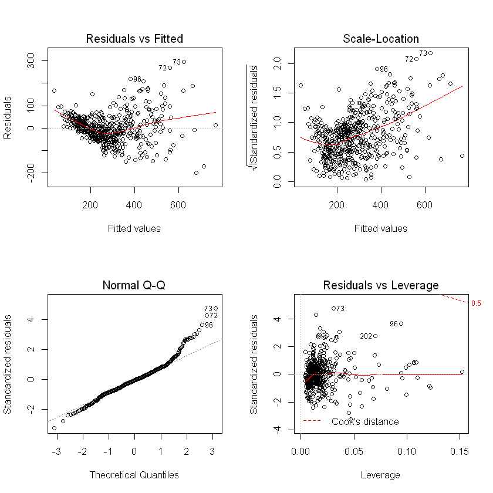

```r
layout(matrix(c(1,2,3,4),2,2))
plot(new_model)
```

From the first plot we see that our residuals have non-linear patterns.And also we can see there some sign of the heteroscedasticity.Spread of our residuals are getting bigger as our fitted values are increasing. We can regulate this with GLS or FGLS.

In the second plot we see quite the same as in the first one: nonlinearity of residuals and some heteroscedasticity. And we have to apply the same techniques as in the first case to get rid of heteroscedasticity.

In the third plot we can say that our residuals are normaldistributed with some extrem values.

And in the fourth plot we see that we have no influential outliers in our model. All points are lying in the Cook's distance.

```r
VIF(new_model)
```

4.79499619940548

This is our VIF for our new subset model. As it was said in lection if vif is larger than 4 then it's a reason for concern. And maybe we would try to fit some reguralized models to get rid of Multicollinearity. For example: Ridge Regression.

```r
VIF(d_V)
```

4.8121285830025

In our full model vif is big enough too. It means everything, what was said about subset model, apllies here as well.

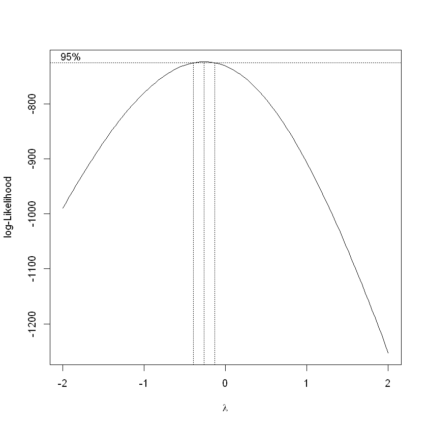

```r
new_model2 = lm(SalesPrice~SqFeet+Beds+AirCond+Garage+Year+Quality+Style+Lot+Highway,data = r_est)
x=boxcox(new_model2, lambda = seq(-2, 2, 1/10))
```

```r
x$x[which(x$y==max(x$y))]
```

-0.262626262626263

```r
lambda = -0.262626262626263
 r_est$SalesPrice = ((r_est$SalesPrice)^(lambda)-1)/lambda
```

And now we transform with the help of this lambda our response value. And fit our model again to see, whether there are some improvements.

```r
new_model2 = lm(SalesPrice~SqFeet+Beds+AirCond+Garage+Year+Quality+Style+Lot+Highway,data = r_est)
summary(new_model2)
```

```
Call:
lm(formula = SalesPrice ~ SqFeet + Beds + AirCond + Garage +
    Year + Quality + Style + Lot + Highway, data = r_est)

Residuals:
      Min        1Q    Median        3Q       Max
-0.145899 -0.025223  0.000449  0.028033  0.124799

Coefficients:
              Estimate Std. Error t value Pr(>|t|)
(Intercept)  0.9638719  0.2800452   3.442 0.000625 ***
SqFeet       0.0762047  0.0047777  15.950  < 2e-16 ***
Beds         0.0042202  0.0022250   1.897 0.058429 .
AirCond      0.0115551  0.0056177   2.057 0.040202 *
Garage       0.0095251  0.0035731   2.666 0.007924 **
Year         0.0009116  0.0001408   6.475 2.23e-10 ***
Quality     -0.0369583  0.0047270  -7.819 3.08e-14 ***
Style       -0.0029414  0.0009314  -3.158 0.001682 **
Lot          0.0011359  0.0001676   6.776 3.40e-11 ***
Highway     -0.0193674  0.0128416  -1.508 0.132126
---
Signif. codes:  0 '***' 0.001 '**' 0.01 '*' 0.05 '.' 0.1 ' ' 1

Residual standard error: 0.04156 on 511 degrees of freedom
Multiple R-squared:  0.8242,	Adjusted R-squared:  0.8212
F-statistic: 266.3 on 9 and 511 DF,  p-value: < 2.2e-16
```

And as we see our R^(2) adjusted was improved because of this Box-Cox Transformation.

```r
###### Aufgabe 4 ##############
w_r = read.xlsx("WordRecall.xlsx",1)
w_r = w_r[,1:2]
w_r
```

| time | prop |
| --- | --- |
| 1 | 0.84 |
| 5 | 0.71 |
| 15 | 0.61 |
| 30 | 0.56 |
| 60 | 0.54 |
| 120 | 0.47 |
| 240 | 0.45 |
| 480 | 0.38 |
| 720 | 0.36 |
| 1440 | 0.26 |
| 2880 | 0.20 |
| 5760 | 0.16 |
| 10080 | 0.08 |

```r
summary(lm(prop ~ time , data = w_r))
```

```
Call:
lm(formula = prop ~ time, data = w_r)

Residuals:
     Min       1Q   Median       3Q      Max
-0.18564 -0.11913 -0.04495  0.08496  0.31418

Coefficients:
              Estimate Std. Error t value Pr(>|t|)
(Intercept)  5.259e-01  4.881e-02  10.774 3.49e-07 ***
time        -5.571e-05  1.457e-05  -3.825  0.00282 **
---
Signif. codes:  0 '***' 0.001 '**' 0.01 '*' 0.05 '.' 0.1 ' ' 1

Residual standard error: 0.1523 on 11 degrees of freedom
Multiple R-squared:  0.5709,	Adjusted R-squared:  0.5318
F-statistic: 14.63 on 1 and 11 DF,  p-value: 0.002817
```

Here we fit just our untransformed value. Then we will trnasform some variables and fit it again to compare adjusted R^(2).

```r
summary(lm(prop ~ time+1/time, data = w_r))
```

```
Call:
lm(formula = prop ~ time + 1/time, data = w_r)

Residuals:
     Min       1Q   Median       3Q      Max
-0.18564 -0.11913 -0.04495  0.08496  0.31418

Coefficients:
              Estimate Std. Error t value Pr(>|t|)
(Intercept)  5.259e-01  4.881e-02  10.774 3.49e-07 ***
time        -5.571e-05  1.457e-05  -3.825  0.00282 **
---
Signif. codes:  0 '***' 0.001 '**' 0.01 '*' 0.05 '.' 0.1 ' ' 1

Residual standard error: 0.1523 on 11 degrees of freedom
Multiple R-squared:  0.5709,	Adjusted R-squared:  0.5318
F-statistic: 14.63 on 1 and 11 DF,  p-value: 0.002817
```

Here we add 1/time term. As we see it doesn't help at all. Therefore we will try something else.

```r
summary(lm(prop ~ log(time) , data = w_r))
```

```
Call:
lm(formula = prop ~ log(time), data = w_r)

Residuals:
      Min        1Q    Median        3Q       Max
-0.036077 -0.015330 -0.006415  0.017967  0.037799

Coefficients:
             Estimate Std. Error t value Pr(>|t|)
(Intercept)  0.846415   0.014195   59.63 3.65e-15 ***
log(time)   -0.079227   0.002416  -32.80 2.53e-12 ***
---
Signif. codes:  0 '***' 0.001 '**' 0.01 '*' 0.05 '.' 0.1 ' ' 1

Residual standard error: 0.02339 on 11 degrees of freedom
Multiple R-squared:  0.9899,	Adjusted R-squared:  0.989
F-statistic:  1076 on 1 and 11 DF,  p-value: 2.525e-12
```

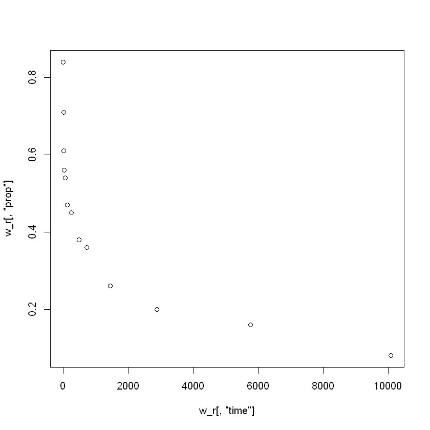

```r
plot(w_r[,"prop"]~w_r[,"time"])
```

Here we transform our predictor with logarithm. And we see that after this transformation our Adjusted R-squared is 0.989. We can say that this transformation does make sense. There are some non-linear patterns on the graph in our data. Therefore it's clear why logarithm transformation improves our model so well.

```r
summary(lm(prop ~ log(time) + 1/time , data = w_r))
```

```
Call:
lm(formula = prop ~ log(time) + 1/time, data = w_r)

Residuals:
      Min        1Q    Median        3Q       Max
-0.036077 -0.015330 -0.006415  0.017967  0.037799

Coefficients:
             Estimate Std. Error t value Pr(>|t|)
(Intercept)  0.846415   0.014195   59.63 3.65e-15 ***
log(time)   -0.079227   0.002416  -32.80 2.53e-12 ***
---
Signif. codes:  0 '***' 0.001 '**' 0.01 '*' 0.05 '.' 0.1 ' ' 1

Residual standard error: 0.02339 on 11 degrees of freedom
Multiple R-squared:  0.9899,	Adjusted R-squared:  0.989
F-statistic:  1076 on 1 and 11 DF,  p-value: 2.525e-12
```

This kind of transformation doesn't help us a lot. R^(2) adjusted stays the same.

```r
predict(lm(prop ~ time , data = w_r), data.frame(time=8) ,interval ="confidence", level=0.95)
```

|  | fit | lwr | upr |
| --- | --- | --- | --- |
| 1 | 0.5254245 | 0.4181291 | 0.6327199 |

```r
predict(lm(prop ~ time + 1/time, data = w_r), data.frame(time=8) ,interval ="confidence", level=0.95)
```

|  | fit | lwr | upr |
| --- | --- | --- | --- |
| 1 | 0.5254245 | 0.4181291 | 0.6327199 |

```r
predict(lm(prop ~ log(time) , data = w_r), data.frame(time=8) ,interval ="confidence", level=0.95)
```

|  | fit | lwr | upr |
| --- | --- | --- | --- |
| 1 | 0.6816677 | 0.6596709 | 0.7036645 |

And as we see here our Confidence Interval is much smaller in compare to untrasformed models.

```r
predict(lm(prop ~ log(time) + 1/time , data = w_r), data.frame(time=8) ,interval ="confidence", level=0.95)
```

|  | fit | lwr | upr |
| --- | --- | --- | --- |
| 1 | 0.6816677 | 0.6596709 | 0.7036645 |

The same Confidence Interval.